# Homework 4

your name here

**Due October 30, 2023 prior to 1:30 PM. Assignments are to be submitted via Canvas.**

**You may discuss the homework problems and computing issues with other students in the class and submit questions to the Canvas discussion board. However, you must write up your homework solution on your own. In particular, do not share your R files with other students. Please list the students you worked with below:**

Students worked with: XXXXX

Lectures: Module 4

Objectives:

1. Quick intro to robust Poisson regression.
2. Fit and interpret a GEE.
3. Understand working correlations.
4. Compare conditional and marginal coefficient estimates in logistic regression with clustered data.

# 1 Robust Poisson regression

Although GEEs are used for clustered data, the package `gee` can also be used for robust regression with just one observation per subject.

**1.1** Run the code below. Then fit the Poisson glm with overdispersion and response `Cases` with `c_households`, `c_nohs`, `c_uninsured`, `c_vacant`, and `logPop100k` as an offset, where `c_households` is centered households (the same model as in HW3, 1.13). Then fit the GEE model with the same covariates using `gee::gee`. Hint: create a variable `id` as `1:nrow(dat)` to use as a clustering variable, with just one observation per cluster.

```r
hiv_cases = read.csv('AtlasPlusTableData_HIV_2016.csv')
socdet = read.csv('AtlasPlusTableData_SocialDeterminants_2016.csv')
library(tidyr)
socdet_wide = socdet%>%pivot_wider(names_from = Indicator, values_from=Percent)
dat = merge(hiv_cases,socdet_wide)
dat$Pop100k = dat$Cases/dat$Rate.per.100000
dat$logPop100k = log(dat$Pop100k)
dat$c_households = scale(dat$`Households living below the federal poverty level`,scale = FALSE)
dat$c_nohs = scale(dat$`Population 25 years and older w/o HS diploma`,scale = FALSE)
dat$c_uninsured = scale(dat$Uninsured,scale = FALSE)
dat$c_vacant = scale(dat$`Vacant housing`,scale=FALSE)
```

```r
hw3.model6 = glm(Cases~c_households+c_nohs+c_uninsured+c_vacant,
                 offset = log(Pop100k),data=dat,family=quasipoisson)

summary(hw3.model6)
```

```
##
## Call:
## glm(formula = Cases ~ c_households + c_nohs + c_uninsured + c_vacant,
##     family = quasipoisson, data = dat, offset = log(Pop100k))
##
## Deviance Residuals:
##     Min       1Q   Median       3Q      Max
## -14.475   -8.308   -4.748    0.446   26.364
##
## Coefficients:
##              Estimate Std. Error t value Pr(>|t|)
## (Intercept)   2.55040    0.07120  35.820   <2e-16 ***
## c_households  0.00475    0.04508   0.105   0.9165
## c_nohs        0.06239    0.03400   1.835   0.0730 .
## c_uninsured   0.03365    0.01902   1.769   0.0835 .
## c_vacant      0.02963    0.02317   1.279   0.2074
## ---
## Signif. codes:  0 '***' 0.001 '**' 0.01 '*' 0.05 '.' 0.1 ' ' 1
##
## (Dispersion parameter for quasipoisson family taken to be 121.6911)
##
##     Null deviance: 8266.7  on 50  degrees of freedom
## Residual deviance: 4786.4  on 46  degrees of freedom
## AIC: NA
##
## Number of Fisher Scoring iterations: 4
```

```r
dat$id = 1:nrow(dat)
model1.1 = gee::gee(Cases~c_households+c_nohs+c_uninsured+c_vacant+offset(logPop100k),
                    id = id,
                    family = poisson, data=dat)
```

```
## Beginning Cgee S-function, @(#) geeformula.q 4.13 98/01/27
```

```
## running glm to get initial regression estimate
```

```
##  (Intercept) c_households       c_nohs  c_uninsured     c_vacant
##   2.55040411   0.00475001   0.06239397   0.03365001   0.02963076
```

```r
summary(model1.1)
```

```
##
##  GEE:  GENERALIZED LINEAR MODELS FOR DEPENDENT DATA
##  gee S-function, version 4.13 modified 98/01/27 (1998)
##
## Model:
##  Link:                      Logarithm
##  Variance to Mean Relation: Poisson
##  Correlation Structure:     Independent
##
## Call:
## gee::gee(formula = Cases ~ c_households + c_nohs + c_uninsured +
##     c_vacant + offset(logPop100k), id = id, data = dat, family = poisson)
##
## Summary of Residuals:
##         Min          1Q      Median          3Q         Max
##   -6.896284   82.694955  341.451884  812.967125 5050.923599
##
##
## Coefficients:
##                Estimate Naive S.E.    Naive z Robust S.E.    Robust z
## (Intercept)  2.55040411 0.07120029 35.8201350  0.07026979 36.29446078
## c_households 0.00475001 0.04508125  0.1053655  0.05564390  0.08536444
## c_nohs       0.06239397 0.03400387  1.8349080  0.03401832  1.83412840
## c_uninsured  0.03365001 0.01901816  1.7693617  0.01911716  1.76019973
## c_vacant     0.02963076 0.02316927  1.2788817  0.03106992  0.95367965
##
## Estimated Scale Parameter:  121.6883
## Number of Iterations:  1
##
## Working Correlation
##      [,1]
## [1,]    1
```

**1.2** How do the t statistics from `glm` compare to the naive z from `gee`?

```r
t1.2 = cbind(summary(hw3.model6)$coefficients[,'t value'],
             summary(model1.1)$coefficients[, 'Naive z'])
colnames(t1.2) = c('glm t-statistics', 'gee naive z')
pander::pander(t1.2)
```

|  | glm t-statistics | gee naive z |
| --- | --- | --- |
| **(Intercept)** | 35.82 | 35.82 |
| **c_households** | 0.1054 | 0.1054 |
| **c_nohs** | 1.835 | 1.835 |
| **c_uninsured** | 1.769 | 1.769 |
| **c_vacant** | 1.279 | 1.279 |

The t statistics from glm are the same as the naive z from gee.

**1.3** How do the t-statistics from `glm` compare to the robust z from `gee`?

```r
t1.2 = cbind(summary(hw3.model6)$coefficients[,'t value'],
             summary(model1.1)$coefficients[, 'Robust z'])
colnames(t1.2) = c('glm t-statistics', 'gee robust z')
pander::pander(t1.2)
```

|  | glm t-statistics | gee robust z |
| --- | --- | --- |
| **(Intercept)** | 35.82 | 36.29 |
| **c_households** | 0.1054 | 0.08536 |
| **c_nohs** | 1.835 | 1.834 |
| **c_uninsured** | 1.769 | 1.76 |
| **c_vacant** | 1.279 | 0.9537 |

The t-statistics from glm are slightly larger than the robust z from gee, except for intercept.

# 2 GEEs for Gaussian data: multiband data from HW2.

In this problem, we will continue working with the multiband dataset on connectivity between the right and left thalamus. We will use `geepack`, which is an alternative package for fitting GEEs.

**2.1** REVIEW: First, make the reference level for `Acquisition` equal to `SB.2.mm`. Then refit the mixed model with `Acquisition`, `gender`, `scanner`, and random intercept `id`. Create the plot of the residuals and restate the major issue previously identified.

```r
library(lmerTest)
mbdata = read.csv("thalamus_mb_selected.csv")
mbdata$Acquisition = relevel(factor(mbdata$Acquisition), ref = 'SB.2.mm')
hw2.model1.8 = lmer(zcor~Acquisition+gender+scanner+(1|id),
              data = mbdata)
summary(hw2.model1.8)
```

```
## Linear mixed model fit by REML. t-tests use Satterthwaite's method [
## lmerModLmerTest]
## Formula: zcor ~ Acquisition + gender + scanner + (1 | id)
##    Data: mbdata
##
## REML criterion at convergence: -23.2
##
## Scaled residuals:
##     Min      1Q  Median      3Q     Max
## -2.4601 -0.6332 -0.0724  0.5658  3.5088
##
## Random effects:
##  Groups   Name        Variance Std.Dev.
##  id       (Intercept) 0.01071  0.1035
##  Residual             0.04069  0.2017
## Number of obs: 277, groups:  id, 32
##
## Fixed effects:
##                        Estimate Std. Error         df t value Pr(>|t|)
## (Intercept)            0.541508   0.053201  82.369049  10.179 3.16e-16 ***
## AcquisitionMB.12      -0.359084   0.050871 237.529345  -7.059 1.84e-11 ***
## AcquisitionMB.2        0.069437   0.051784 238.331414   1.341    0.181
## AcquisitionMB.3       -0.045796   0.052285 238.723676  -0.876    0.382
## AcquisitionMB.4        0.022137   0.051315 237.992504   0.431    0.667
## AcquisitionMB.6       -0.082737   0.050871 237.529345  -1.626    0.105
## AcquisitionMB.8       -0.309769   0.050871 237.529345  -6.089 4.52e-09 ***
## AcquisitionMB.9       -0.298630   0.052272 238.549180  -5.713 3.29e-08 ***
## AcquisitionSB.3.3.mm   0.337458   0.051315 237.992471   6.576 3.03e-10 ***
## genderM                0.028298   0.044288  29.135197   0.639    0.528
## scannerCSIC           -0.007675   0.045914  29.541255  -0.167    0.868
## ---
## Signif. codes:  0 '***' 0.001 '**' 0.01 '*' 0.05 '.' 0.1 ' ' 1
##
## Correlation of Fixed Effects:
##             (Intr) AMB.12 AcMB.2 AcMB.3 AcMB.4 AcMB.6 AcMB.8 AcMB.9 ASB.3.
## AcqstnMB.12 -0.491
## AcqustnMB.2 -0.475  0.500
## AcqustnMB.3 -0.465  0.495  0.490
## AcqustnMB.4 -0.481  0.504  0.495  0.492
## AcqustnMB.6 -0.491  0.509  0.500  0.495  0.504
## AcqustnMB.8 -0.491  0.509  0.500  0.495  0.504  0.509
## AcqustnMB.9 -0.473  0.495  0.486  0.483  0.492  0.495  0.495
## AcqsSB.3.3. -0.481  0.504  0.497  0.492  0.500  0.504  0.504  0.491
## genderM     -0.353  0.004  0.005  0.000 -0.001  0.004  0.004 -0.011 -0.001
## scannerCSIC -0.493  0.005 -0.008 -0.015 -0.001  0.005  0.005  0.007 -0.001
##             gendrM
## AcqstnMB.12
## AcqustnMB.2
## AcqustnMB.3
## AcqustnMB.4
## AcqustnMB.6
## AcqustnMB.8
## AcqustnMB.9
## AcqsSB.3.3.
## genderM
## scannerCSIC -0.124
```

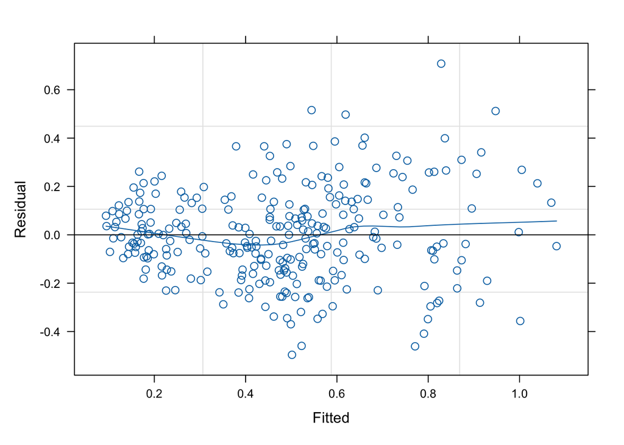

```r
plot(hw2.model1.8, type = c("p", "smooth"),
     xlab = "Fitted", ylab = "Residual")
```

The fitted versus residual plot is used to check the linearity assumption and homoscedasticity. The blue line is not flat, which indicates a violation of the linearity assumption. The residuals are more spread out for large fitted values, indicating a violation of homoscedasticity.

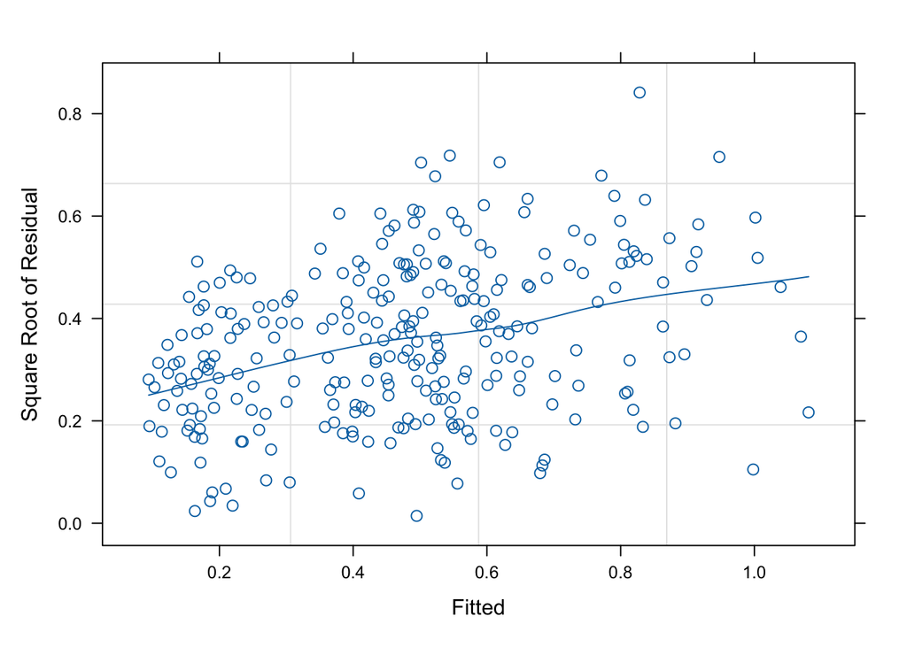

```r
plot(hw2.model1.8, sqrt(abs(resid(.))) ~ fitted(.), type = c("p", "smooth"),
     xlab = "Fitted", ylab = "Square Root of Residual")
```

The scale-location plot is used to check the homoscedasticity. The blue line is not flat, which indicates a violation of homoscedasticity.

**2.2** What is the ICC?

```r
# extract tau^2 and sigma^2
tau2 <- VarCorr(hw2.model1.8)$id[1]
sigma2 <- summary(hw2.model1.8)$sigma^2

# compute icc
icc <- tau2 / (tau2 + sigma2)
print(icc)
```

```
## [1] 0.2083146
```

The ICC is 0.2083146.

**2.3** Now, fit a gee with the same fixed effects and exchangeable working correlation structure using `geepack::geeglm`. Print the output of summary.

```r
model2.3 = geepack::geeglm(zcor~Acquisition+gender+scanner,
              data = mbdata, id=id, corstr='exchangeable')
summary(model2.3)
```

```
##
## Call:
## geepack::geeglm(formula = zcor ~ Acquisition + gender + scanner,
##     data = mbdata, id = id, corstr = "exchangeable")
##
##  Coefficients:
##                       Estimate   Std.err    Wald Pr(>|W|)
## (Intercept)           0.541497  0.049401 120.147  < 2e-16 ***
## AcquisitionMB.12     -0.359072  0.048418  54.997 1.21e-13 ***
## AcquisitionMB.2       0.069463  0.052531   1.749    0.186
## AcquisitionMB.3      -0.045716  0.057608   0.630    0.427
## AcquisitionMB.4       0.022201  0.051865   0.183    0.669
## AcquisitionMB.6      -0.082725  0.052998   2.436    0.119
## AcquisitionMB.8      -0.309756  0.049083  39.828 2.77e-10 ***
## AcquisitionMB.9      -0.298536  0.048475  37.927 7.34e-10 ***
## AcquisitionSB.3.3.mm  0.337407  0.074676  20.415 6.23e-06 ***
## genderM               0.028338  0.042338   0.448    0.503
## scannerCSIC          -0.007707  0.042247   0.033    0.855
## ---
## Signif. codes:  0 '***' 0.001 '**' 0.01 '*' 0.05 '.' 0.1 ' ' 1
##
## Correlation structure = exchangeable
## Estimated Scale Parameters:
##
##             Estimate  Std.err
## (Intercept)  0.04885 0.004875
##   Link = identity
##
## Estimated Correlation Parameters:
##       Estimate Std.err
## alpha   0.1973 0.05464
## Number of clusters:   32  Maximum cluster size: 9
```

**2.4** What is the ICC in the gee?

$\rho = \alpha$ = 0.197

**2.5** What is the test statistic for Acquisition MB=8 in the gee with exchangeable working correlation structure? How does it compare to the linear mixed model? (Note: the Wald statistic in geepack::geeglm corresponds to the robust variance estimator).

```r
summary(model2.3)$coefficients['AcquisitionMB.8',]
```

```
##                 Estimate Std.err  Wald  Pr(>|W|)
## AcquisitionMB.8  -0.3098 0.04908 39.83 2.774e-10
```

```r
summary(hw2.model1.8)$coefficients['AcquisitionMB.8',]
```

```
##   Estimate Std. Error         df    t value   Pr(>|t|)
## -3.098e-01  5.087e-02  2.375e+02 -6.089e+00  4.525e-09
```

The test statistic for Acquisition MB=8 in the gee with exchangeable working correlation structure is 39.83, which is larger than the square of the t-statistic from linear mixed model: $39.83 > (-6.089)^2$.

**2.6** Now fit the same gee but with unstructured working correlation. Print the output of summary.

```r
model2.6 = geepack::geeglm(zcor~Acquisition+gender+scanner,
              data = mbdata, id=id, corstr='unstructured')
print(summary(model2.6))
```

```
##
## Call:
## geepack::geeglm(formula = zcor ~ Acquisition + gender + scanner,
##     data = mbdata, id = id, corstr = "unstructured")
##
##  Coefficients:
##                       Estimate   Std.err   Wald Pr(>|W|)
## (Intercept)           0.496089  0.049231 101.54  < 2e-16 ***
## AcquisitionMB.12     -0.267154  0.048087  30.87  2.8e-08 ***
## AcquisitionMB.2       0.115872  0.056306   4.24    0.040 *
## AcquisitionMB.3       0.009682  0.049726   0.04    0.846
## AcquisitionMB.4       0.058221  0.053463   1.19    0.276
## AcquisitionMB.6      -0.085973  0.049816   2.98    0.084 .
## AcquisitionMB.8      -0.249469  0.046270  29.07  7.0e-08 ***
## AcquisitionMB.9      -0.224949  0.049610  20.56  5.8e-06 ***
## AcquisitionSB.3.3.mm  0.336050  0.069141  23.62  1.2e-06 ***
## genderM               0.028536  0.039856   0.51    0.474
## scannerCSIC          -0.000464  0.039161   0.00    0.991
## ---
## Signif. codes:  0 '***' 0.001 '**' 0.01 '*' 0.05 '.' 0.1 ' ' 1
##
## Correlation structure = unstructured
## Estimated Scale Parameters:
##
##             Estimate Std.err
## (Intercept)   0.0499  0.0051
##   Link = identity
##
## Estimated Correlation Parameters:
##           Estimate Std.err
## alpha.1:2   0.2513  0.1138
## alpha.1:3   0.0599  0.1467
## alpha.1:4   0.1731  0.1356
## alpha.1:5   0.0879  0.0935
## alpha.1:6  -0.0908  0.1554
## alpha.1:7   0.1433  0.1296
## alpha.1:8   0.4098  0.2342
## alpha.1:9   0.3227  0.1681
## alpha.2:3   0.0112  0.1761
## alpha.2:4   0.2832  0.1335
```

[output cut: 12 more lines]

```
## alpha.4:6   0.2712  0.2291
## alpha.4:7   0.2127  0.1651
## alpha.4:8   0.1256  0.2240
## alpha.4:9   0.5242  0.2439
## alpha.5:6   0.1366  0.2307
## alpha.5:7   0.1154  0.1212
## alpha.5:8   0.2464  0.2130
## alpha.5:9   0.4694  0.2909
## alpha.6:7   0.0554  0.2021
## alpha.6:8   0.0995  0.2549
## alpha.6:9   0.0528  0.2747
## alpha.7:8   0.1985  0.1674
## alpha.7:9   0.5198  0.1318
## alpha.8:9   0.5075  0.2548
## Number of clusters:   32  Maximum cluster size: 9
```

**2.7** Let $i$ denote participant and $j$ denote sample, here coinciding with single-band 2 mm ($j=1$), multiband=12 ($j=2$), multiband 2 ($j=3$), …, $j=9$ corresponds to SB.3.3.mm. What is $Corr(y_{i1},y_{i8})$ according to this model? What is $Corr(y_{i2},y_{i9})$?

$Corr(y_{i1},y_{i8})$ = 0.4098; $Corr(y_{i2},y_{i9})$ = 0.2847.

**2.8** Use `geepack::QIC` to select between the exchangeable and unstructured correlation structure. QIC is interpreted in the same way as AIC. (Some authors have criticized QIC, but others have argued it is useful.) For more information about QIC, see Pan 2001 in the Readings, where QIC is defined in equation 8. Which working correlation is preferred?

```r
library(geepack)
qic_exch <- QIC(model2.3)['QIC']
qic_unstr <- QIC(model2.6)['QIC']
qic_exch
```

```
##  QIC
## 41.1
```

```r
qic_unstr
```

```
##  QIC
## 38.7
```

The QIC is 41.071 for the model with exchangeable correlation structure and 38.699 for the model with unstructured correlation structure. A smaller QIC value indicates a better fit. Thus, the unstructured correlation structure is preferred.

# 3

In this problem, we will analyze a dataset from a randomized control trial with 80 women. We are interested in predicting health status (good or poor) controlling for age group and time and including an interaction between age group and treatment.

```r
library(readr)
library(dplyr)
health = read_csv("health.csv") %>%
janitor::clean_names()
health = health %>% mutate(
health = case_when(health=='Poor'~0, TRUE ~ 1),
agegroup = factor(agegroup),
treatment = factor(txt, levels = c("Control","Intervention")),
time_months = case_when(time == 1 ~ 0, time == 2 ~ 3, time == 3 ~ 6, TRUE ~ 12), time = factor(time))
```

**3.1.** Fit the glmm with outcome `health`, predictors `time_months`, `treatment`, `agegroup`, the interaction between `treatment` and `agegroup`, and a random intercept for `id`. First, fit the model with the default optimization (no argument for nAQG, i.e. Laplace Approximation). Print the output of summary.

```r
model3.1 <- glmer(health ~ time_months + treatment + agegroup +
                   treatment:agegroup + (1|id),
                   data = health,
                   family = binomial(link="logit"))

summary(model3.1)
```

```
## Generalized linear mixed model fit by maximum likelihood (Laplace
##   Approximation) [glmerMod]
##  Family: binomial  ( logit )
## Formula: health ~ time_months + treatment + agegroup + treatment:agegroup +
##     (1 | id)
##    Data: health
##
##      AIC      BIC   logLik deviance df.resid
##      328      357     -156      312      271
##
## Scaled residuals:
##    Min     1Q Median     3Q    Max
## -2.832 -0.505  0.319  0.508  2.327
##
## Random effects:
##  Groups Name        Variance Std.Dev.
##  id     (Intercept) 2.32     1.52
## Number of obs: 279, groups:  id, 80
##
## Fixed effects:
##                                     Estimate Std. Error z value Pr(>|z|)
## (Intercept)                           -1.256      0.514   -2.44   0.0145 *
## time_months                            0.143      0.043    3.32   0.0009 ***
## treatmentIntervention                  2.041      0.720    2.83   0.0046 **
## agegroup25-34                          1.488      0.716    2.08   0.0377 *
## agegroup35+                            1.131      1.123    1.01   0.3140
## treatmentIntervention:agegroup25-34   -1.500      1.017   -1.48   0.1401
## treatmentIntervention:agegroup35+     -1.761      1.681   -1.05   0.2946
## ---
## Signif. codes:  0 '***' 0.001 '**' 0.01 '*' 0.05 '.' 0.1 ' ' 1
##
## Correlation of Fixed Effects:
##             (Intr) tm_mnt trtmnI a25-34 agg35+ tI:25-
## time_months -0.361
## trtmntIntrv -0.662  0.080
## agegrp25-34 -0.645  0.031  0.476
## agegroup35+ -0.411  0.022  0.301  0.299
## trtmI:25-34  0.458 -0.032 -0.704 -0.705 -0.211
## trtmntI:35+  0.291 -0.051 -0.433 -0.208 -0.673  0.304
```

**3.2.** Next, refit the model with nAGQ=50. Do the results differ? Use nAGQ=50 in the results that follow.

```r
model3.2 <- glmer(health ~ time_months + treatment + agegroup +
                   treatment:agegroup + (1|id),
                   data = health,
                   nAGQ = 50,
                   family = binomial(link="logit"))

summary(model3.2)
```

```
## Generalized linear mixed model fit by maximum likelihood (Adaptive
##   Gauss-Hermite Quadrature, nAGQ = 50) [glmerMod]
##  Family: binomial  ( logit )
## Formula: health ~ time_months + treatment + agegroup + treatment:agegroup +
##     (1 | id)
##    Data: health
##
##      AIC      BIC   logLik deviance df.resid
##      325      354     -155      309      271
##
## Scaled residuals:
##    Min     1Q Median     3Q    Max
## -2.896 -0.470  0.307  0.501  2.390
##
## Random effects:
##  Groups Name        Variance Std.Dev.
##  id     (Intercept) 2.86     1.69
## Number of obs: 279, groups:  id, 80
##
## Fixed effects:
##                                     Estimate Std. Error z value Pr(>|z|)
## (Intercept)                          -1.2762     0.5443   -2.34  0.01904 *
## time_months                           0.1465     0.0439    3.33  0.00086 ***
## treatmentIntervention                 2.0624     0.7640    2.70  0.00695 **
## agegroup25-34                         1.5117     0.7636    1.98  0.04774 *
## agegroup35+                           1.1542     1.2008    0.96  0.33644
## treatmentIntervention:agegroup25-34  -1.5228     1.0824   -1.41  0.15947
## treatmentIntervention:agegroup35+    -1.7932     1.7946   -1.00  0.31769
## ---
## Signif. codes:  0 '***' 0.001 '**' 0.01 '*' 0.05 '.' 0.1 ' ' 1
##
## Correlation of Fixed Effects:
##             (Intr) tm_mnt trtmnI a25-34 agg35+ tI:25-
## time_months -0.346
## trtmntIntrv -0.665  0.079
## agegrp25-34 -0.646  0.030  0.473
## agegroup35+ -0.411  0.022  0.299  0.297
## trtmI:25-34  0.459 -0.031 -0.702 -0.706 -0.209
## trtmntI:35+  0.289 -0.048 -0.430 -0.204 -0.673  0.301
```

The results slightly differ.

**3.3** What is the odds ratio and 95% confidence interval for treatment=Intervention in age group 25-34 versus Control in age group 25-34?

```r
coefs = summary(model3.2)$coefficients
coef_inter = coefs['treatmentIntervention', 'Estimate']
coef_age25_34_inter = coefs['treatmentIntervention:agegroup25-34', 'Estimate']
odds_ratio = exp(coef_inter + coef_age25_34_inter)
odds_ratio
```

```
## [1] 1.72
```

```r
cov_odds <- coefs['treatmentIntervention', 'Std. Error']^2 +
            coefs['treatmentIntervention:agegroup25-34', 'Std. Error']^2 +
            2 * vcov(model3.2)["treatmentIntervention",
                               "treatmentIntervention:agegroup25-34"]

(lower = exp(coef_inter + coef_age25_34_inter - 1.96 * sqrt(cov_odds)))
```

```
## [1] 0.378
```

```r
(upper = exp(coef_inter + coef_age25_34_inter + 1.96 * sqrt(cov_odds)))
```

```
## [1] 7.78
```

The odds ratio is 1.715, and 95% confidence interval is (0.378, 7.777).

**3.4** Write out a gee model with outcome `health`, predictors `treatment`, `agegroup`, `treatment*agegroup`, and `time_months`, and exchangeable working correlation. Note: you can adapt this latex code
$$R_i =
\pmatrix{1 & a & b & c \\ d & 1 & e & f \\ g
& h & 1 & i \\ j & k & l & 1}.$$

Let $y_{ij}$ be the `health` outcome of subject $i$ at months $j$ and $\textbf{y}_i = (y_{i1}, y_{i2}, \cdots, y_{ij})$ be the vector of `health` outcomes for subject $i$,

$$y_{ij} \sim Bernoulli(p_{ij})\\
logit(p_{ij}) = \beta_{0} + \beta_{1}*\text{months}_{ij}+
\beta_{2}*I(Treatment_{ij}=Intervention) + \beta_{3}*I(age_{ij}=25-34)+
\beta_{4}*I(age_{ij}=35+) + \\
\beta_{5}*I(Treatment_{ij}=Intervention)*I(age_{ij}=25-34) + \beta_{6} *
I(Treatment_{ij}=Intervention)*I(age_{ij}=35+) \\
Cov(\textbf{y}_i) = \phi \textbf{D}_i^{1/2} \textbf{R}_i (\alpha)
\textbf{D}_i^{1/2}$$
where $\phi$ is the scale parameter; $\textbf{D}_i$ is diagonal matrix where the $j^{th}$ diagonal element $\textbf{D}_{i, [j,j]} = p_{ij} \times (1 - p_{ij})$, representing the marginal variance; and

$$\textbf{R}_i(\alpha) = \pmatrix{1 & \alpha & \alpha & \alpha
\\ \alpha & 1 & \alpha & \alpha \\ \alpha & \alpha &
1 & \alpha \\ \alpha & \alpha & \alpha & 1}.$$

**3.5** Fit the gee with outcome `health`, predictors `treatment`, `agegroup`, `treatment*agegroup`, and `time_months`, and exchangeable working correlation. Print the output of summary and comment on how the direction of effects and p values compare to the glmm.

```r
model3.5 <- geeglm(health ~ treatment + agegroup + treatment:agegroup
                   + time_months,
                   data = health,
                   id = id,
                   family = binomial,
                   corstr = "exchangeable")
summary(model3.5)
```

```
##
## Call:
## geeglm(formula = health ~ treatment + agegroup + treatment:agegroup +
##     time_months, family = binomial, data = health, id = id, corstr = "exchangeable")
##
##  Coefficients:
##                                     Estimate Std.err  Wald Pr(>|W|)
## (Intercept)                          -0.8679  0.4187  4.30   0.0382 *
## treatmentIntervention                 1.3830  0.5380  6.61   0.0101 *
## agegroup25-34                         1.0926  0.5693  3.68   0.0550 .
## agegroup35+                           0.7453  0.7759  0.92   0.3368
## time_months                           0.0984  0.0311 10.05   0.0015 **
## treatmentIntervention:agegroup25-34  -1.0624  0.7322  2.11   0.1468
## treatmentIntervention:agegroup35+    -1.1569  0.9206  1.58   0.2089
## ---
## Signif. codes:  0 '***' 0.001 '**' 0.01 '*' 0.05 '.' 0.1 ' ' 1
##
## Correlation structure = exchangeable
## Estimated Scale Parameters:
##
##             Estimate Std.err
## (Intercept)    0.973  0.0946
##   Link = identity
##
## Estimated Correlation Parameters:
##       Estimate Std.err
## alpha     0.31  0.0969
## Number of clusters:   80  Maximum cluster size: 4
```

```r
glmm_coefs = coefs[, 'Estimate']
gee_coefs = summary(model3.5)$coefficients[, 'Estimate']
pander::pander(cbind(glmm_coefs, gee_coefs))
```

|  | glmm_coefs | gee_coefs |
| --- | --- | --- |
| **(Intercept)** | -1.276 | -0.8679 |
| **time_months** | 0.1465 | 1.383 |
| **treatmentIntervention** | 2.062 | 1.093 |
| **agegroup25-34** | 1.512 | 0.7453 |
| **agegroup35+** | 1.154 | 0.09844 |
| **treatmentIntervention:agegroup25-34** | -1.523 | -1.062 |
| **treatmentIntervention:agegroup35+** | -1.793 | -1.157 |

```r
glmm_p = coefs[, 'Pr(>|z|)']
gee_p = summary(model3.5)$coefficients[, 'Pr(>|W|)']
pander::pander(cbind(glmm_p, gee_p))
```

|  | glmm_p | gee_p |
| --- | --- | --- |
| **(Intercept)** | 0.01904 | 0.0382 |
| **time_months** | 0.0008562 | 0.01015 |
| **treatmentIntervention** | 0.006946 | 0.05498 |
| **agegroup25-34** | 0.04774 | 0.3368 |
| **agegroup35+** | 0.3364 | 0.001524 |
| **treatmentIntervention:agegroup25-34** | 0.1595 | 0.1468 |
| **treatmentIntervention:agegroup35+** | 0.3177 | 0.2089 |

The direction of effects from gee and glmm are the same. The p-values are quite differnt.

**3.6** What is the value of $\alpha$? What is $Corr(y_{i1},y_{i4})$?

$\alpha$ is 0.31. $Corr(y_{i1},y_{i4})$ is 0.31.

**3.7** Fit the gee with outcome `health`, predictors `treatment`, `agegroup`, `treatment*agegroup`, and `time_months`, and AR1 working correlation. NOTE: check that the data are sorted correctly. Print the output of summary.

```r
health_sorted <- health %>% arrange(id, time_months)

model3.7 <- geeglm(health ~ treatment + agegroup + treatment:agegroup
                   + time_months,
                   data = health,
                   id = id,
                   family = binomial,
                   corstr = "ar1")
summary(model3.7)
```

```
##
## Call:
## geeglm(formula = health ~ treatment + agegroup + treatment:agegroup +
##     time_months, family = binomial, data = health, id = id, corstr = "ar1")
##
##  Coefficients:
##                                     Estimate Std.err Wald Pr(>|W|)
## (Intercept)                          -0.8341  0.4232 3.88   0.0487 *
## treatmentIntervention                 1.3267  0.5429 5.97   0.0145 *
## agegroup25-34                         0.9401  0.5716 2.70   0.1000
## agegroup35+                           0.6168  0.7465 0.68   0.4087
## time_months                           0.0966  0.0307 9.87   0.0017 **
## treatmentIntervention:agegroup25-34  -1.0010  0.7382 1.84   0.1751
## treatmentIntervention:agegroup35+    -0.9191  0.9048 1.03   0.3097
## ---
## Signif. codes:  0 '***' 0.001 '**' 0.01 '*' 0.05 '.' 0.1 ' ' 1
##
## Correlation structure = ar1
## Estimated Scale Parameters:
##
##             Estimate Std.err
## (Intercept)     0.95  0.0634
##   Link = identity
##
## Estimated Correlation Parameters:
##       Estimate Std.err
## alpha    0.425  0.0996
## Number of clusters:   80  Maximum cluster size: 4
```

**3.8** What is the value of the AR1 coefficient? What is $Corr(y_{i1},y_{i4})$?

The AR1 coefficient is 0.425, $Corr(y_{i1},y_{i4}) = 0.425^3 = 0.0768$.

**3.9** What is the odds ratio and 95% confidence interval for treatment=Intervention in age group 25-34 versus Control in age group 25-34? How does this compare to the GLMM?

```r
coefs = summary(model3.7)$coefficients
coef_inter = coefs['treatmentIntervention', 'Estimate']
coef_age25_34_inter = coefs['treatmentIntervention:agegroup25-34', 'Estimate']
odds_ratio = exp(coef_inter + coef_age25_34_inter)
odds_ratio
```

```
## [1] 1.39
```

```r
cov_odds <- coefs['treatmentIntervention', 'Std.err']^2 +
            coefs['treatmentIntervention:agegroup25-34', 'Std.err']^2 +
            2 * vcov(model3.7)["treatmentIntervention",
                               "treatmentIntervention:agegroup25-34"]

(lower = exp(coef_inter + coef_age25_34_inter - 1.96 * sqrt(cov_odds)))
```

```
## [1] 0.519
```

```r
(upper = exp(coef_inter + coef_age25_34_inter + 1.96 * sqrt(cov_odds)))
```

```
## [1] 3.69
```

The odds ratio is 1.385, and 95% confidence interval is (0.519, 3.693). The OR estimate from gee model is slightly smaller than that from glmm. The 95% CI from gee model is narrower than that from glmm.

**3.10** Does age group modify the effect of treatment? State the null hypothesis, conduct a statistical test, and state your conclusion. Use the AR1 working correlation structure.

```r
# Fit the GEE model with AR1 working correlation
model3.10 <- geeglm(health ~ treatment + agegroup + time_months,
                   data = health,
                   id = id,
                   family = binomial,
                   corstr = "ar1")

anova(model3.10, model3.7)
```

```
## Analysis of 'Wald statistic' Table
##
## Model 1 health ~ treatment + agegroup + treatment:agegroup + time_months
## Model 2 health ~ treatment + agegroup + time_months
##   Df   X2 P(>|Chi|)
## 1  2 2.06      0.36
```

$H_0$: age group does not modify the effect of treatment ($\beta_5$ = $\beta_6$ =0).

The p-value of the test is 0.36 > 0.05. We fail to reject null hypothesis and conclude that age group does not significantly modify the effect of treatment.